# DAM AT1 Part A

Joshua McCarthy

```r
install.packages(tidyverse)
```

```r
library(tidyverse)
```

```r
# Multiple plot function
#
# ggplot objects can be passed in ..., or to plotlist (as a list of ggplot objects)
# - cols:   Number of columns in layout
# - layout: A matrix specifying the layout. If present, 'cols' is ignored.
#
# If the layout is something like matrix(c(1,2,3,3), nrow=2, byrow=TRUE),
# then plot 1 will go in the upper left, 2 will go in the upper right, and
# 3 will go all the way across the bottom.
#
multiplot <- function(..., plotlist=NULL, file, cols=1, layout=NULL) {
  library(grid)

  # Make a list from the ... arguments and plotlist
  plots <- c(list(...), plotlist)

  numPlots = length(plots)

  # If layout is NULL, then use 'cols' to determine layout
  if (is.null(layout)) {
    # Make the panel
    # ncol: Number of columns of plots
    # nrow: Number of rows needed, calculated from # of cols
    layout <- matrix(seq(1, cols * ceiling(numPlots/cols)),
                    ncol = cols, nrow = ceiling(numPlots/cols))
  }

 if (numPlots==1) {
    print(plots[[1]])

  } else {
    # Set up the page
    grid.newpage()
    pushViewport(viewport(layout = grid.layout(nrow(layout), ncol(layout))))

    # Make each plot, in the correct location
    for (i in 1:numPlots) {
      # Get the i,j matrix positions of the regions that contain this subplot
      matchidx <- as.data.frame(which(layout == i, arr.ind = TRUE))

      print(plots[[i]], vp = viewport(layout.pos.row = matchidx$row,
                                      layout.pos.col = matchidx$col))
    }
  }
}
```

```r
p <- purl("AT1_A_EDA_1.Rmd", output = /chunks/)
read_chunk(p)
chunks <- knitr:::knit_code$get()
invisible(mapply(function(chunk, name) {
    writeLines(c(paste0("## ----",name,"----"), chunk), paste0("chunk-",name,".R"))
}, chunks, names(chunks)))
unlink(p) # delete the original purl script
knitr:::knit_code$restore() # remove chunks from current knitr session
```

# 1. EDA

## a. Do you need to clean the data in any way? Justify what you decide to do (or not do).

### what do we do?

provide financial services to a number of clients, each client working in a specified industry group, and in a specified location group. Clients are billed monthly.

### Data

```r
transactions <- read_csv("transactions.csv")
names(transactions)
```

```
## [1] "date"           "customer_id"    "industry"       "location"
## [5] "monthly_amount"
```

```r
str(transactions)
```

```
## Classes 'spec_tbl_df', 'tbl_df', 'tbl' and 'data.frame': 94248 obs. of  5 variables:
##  $ date          : chr  "1/1/13" "1/2/13" "1/3/13" "1/4/13" ...
##  $ customer_id   : chr  "70efdf2ec9b086079795c442636b55fb" "70efdf2ec9b086079795c442636b55fb" "70efdf2ec9b086079795c442636b55fb" "70efdf2ec9b086079795c442636b55fb" ...
##  $ industry      : num  8 8 8 8 8 8 8 8 8 8 ...
##  $ location      : num  9 9 9 9 9 9 9 9 9 9 ...
##  $ monthly_amount: num  753851 651548 1138769 659739 770675 ...
##  - attr(*, "spec")=
##   .. cols(
##   ..   date = col_character(),
##   ..   customer_id = col_character(),
##   ..   industry = col_double(),
##   ..   location = col_double(),
##   ..   monthly_amount = col_double()
##   .. )
```

```r
summary(transactions)
```

```
##      date           customer_id           industry         location
##  Length:94248       Length:94248       Min.   : 1.000   Min.   : 1.000
##  Class :character   Class :character   1st Qu.: 1.000   1st Qu.: 2.000
##  Mode  :character   Mode  :character   Median : 2.000   Median : 4.000
##                                        Mean   : 2.455   Mean   : 4.214
##                                        3rd Qu.: 3.000   3rd Qu.: 6.000
##                                        Max.   :10.000   Max.   :10.000
##  monthly_amount
##  Min.   :        0
##  1st Qu.:    95323
##  Median :   179399
##  Mean   :   395397
##  3rd Qu.:   375439
##  Max.   :100000000
```

```r
range(transactions$date) # range doesn't work on dates?
```

```
## [1] "1/1/13" "1/9/16"
```

```r
sapply(transactions, function(x) length(unique(x))) #number of unique entries for each variable
```

```
##           date    customer_id       industry       location monthly_amount
##             47           4464             10             10          82525
```

*Transactions don’t have unique identifiers (no primary key), relies on composite keys date + customer* Are there any NA’s"?

```r
nrow(transactions) == nrow(na.omit(transactions))
```

```
## [1] TRUE
```

```r
# A. No
```

#### date - Date of the first day of each month

##### Top level info

- Transaction period 1/1/2013 - 1/9/2016 (see below, actual range - 01/11/2016) ** Period of 45 months inclusive (actual 47 months inclusive)

##### Changes to make

- As character -> as posix? / date

```r
transactions$date <- as.Date(transactions$date, format = "%d/%m/%Y")
range(transactions$date) # range doesn't work on dates?
```

```
## [1] "13-01-01" "16-11-01"
```

```r
# date was being read incorrectly
```

- Rename date to avoid conflicts

```r
#not used yet due to legacy code
tname <- names(transactions)
tname[1] <- "trdate"
names(transactions) <- tname
```

##### Questions

- All customer have equal number of transactions over the full period?

```r
number_of_transactions_per_customer <- as.data.frame(table(transactions$customer_id))
head(number_of_transactions_per_customer)
```

```
##                               Var1 Freq
## 1 000a91f3e374e6147d58ed1814247508    8
## 2 0014fcb3db4c8459d26309b177005b10   14
## 3 0023a1e3447fdb31836536cc903f1310   47
## 4 0023daa5a44ef6fbe42379f24e00254c   32
## 5 0029f088c57ad3b6ec589f9ba4f7a057    4
## 6 003af5a042e00ac9b489153a81d676ca    8
```

```r
# A. no
```

- Do any customers have more than one transaction for the same date?

```r
# ggplot(transactions, aes(y = customer_id, x= date)) + geom_point(alpha = 0.25)
# too much data for small area

transactions$duplicated <- transactions %>%
  select(date, customer_id) %>%
  duplicated()

transactions %>%
  filter(duplicated == "TRUE")
```

```
## # A tibble: 0 x 6
## # … with 6 variables: date <date>, customer_id <chr>, industry <dbl>,
## #   location <dbl>, monthly_amount <dbl>, duplicated <lgl>
```

```r
#A. No.
```

```r
transactions <- transactions %>%
  select(-duplicated)
```

- Why are there 47 dates in a 45 month range? The range function was not reading the date as character data correctly
- Breaks in customer relationship?

#### customer_id - Unique customer identifier

##### Top level info

- Hashed customer ID’s

##### Changes to make

- to factors

```r
transactions$customer_id <- as.factor(transactions$customer_id)
```

##### Questions

- How many unique customers?

```r
# table(transactions$customer_id)
# Alot

length(unique(transactions$customer_id))
```

```
## [1] 4464
```

#### industry - Code for 10 industries, ranging from 1 to 10

##### Top level info

- x

##### Changes to make

- To factors

```r
transactions$industry <- as.factor(transactions$industry)
```

##### Questions

- Are all industries represented?

```r
unique(transactions$industry)
```

```
##  [1] 8  1  9  10 2  5  4  6  7  3
## Levels: 1 2 3 4 5 6 7 8 9 10
```

```r
#A. Yes
```

- Do all customers only operate in one industry?

```r
# transactions$multi_industry <-

industry_check <- transactions %>%
  select(industry, customer_id) %>%
  distinct()

industry_check$multi_industry <- industry_check %>%
  select(customer_id) %>%
  duplicated()

industry_check %>%
  filter(multi_industry == "TRUE")
```

```
## # A tibble: 0 x 3
## # … with 3 variables: industry <fct>, customer_id <fct>, multi_industry <lgl>
```

```r
# A. Yes
```

- Customer distribution between industries?

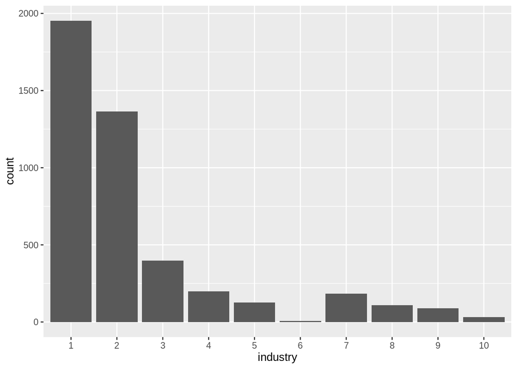

```r
transactions %>%
  distinct(customer_id, industry) %>%
ggplot(aes(x = industry)) + geom_bar()
```

** low participation in industry 6 and 10

```r
customers_industry_6 <- transactions %>%
  distinct(customer_id, industry) %>%
  filter(industry == 6)

count(customers_industry_6)
```

```
## # A tibble: 1 x 1
##       n
##   <int>
## 1     7
```

```r
customers_industry_10 <- transactions %>%
  distinct(customer_id, industry) %>%
  filter(industry == 10)

count(customers_industry_10)
```

```
## # A tibble: 1 x 1
##       n
##   <int>
## 1    32
```

```r
#A. Both still significant, even though under represented
```

#### location - Code for 10 industries, ranging from 1 to 10

##### Top level info

- x

##### Changes to make

- To factors

```r
transactions$location <- as.factor(transactions$location)
```

##### Questions

- Are all locations represented?

```r
unique(transactions$location)
```

```
##  [1] 9  4  2  5  10 6  1  3  8  7
## Levels: 1 2 3 4 5 6 7 8 9 10
```

```r
# A. Yes
```

- Do all customers only operate in one location?

```r
location_check <- transactions %>%
  select(location, customer_id) %>%
  distinct()

location_check$multi_location <- location_check %>%
  select(customer_id) %>%
  duplicated()

location_check %>%
  filter(multi_location == "TRUE")
```

```
## # A tibble: 0 x 3
## # … with 3 variables: location <fct>, customer_id <fct>, multi_location <lgl>
```

```r
# A. Yes
```

- Customer distribution between locations?

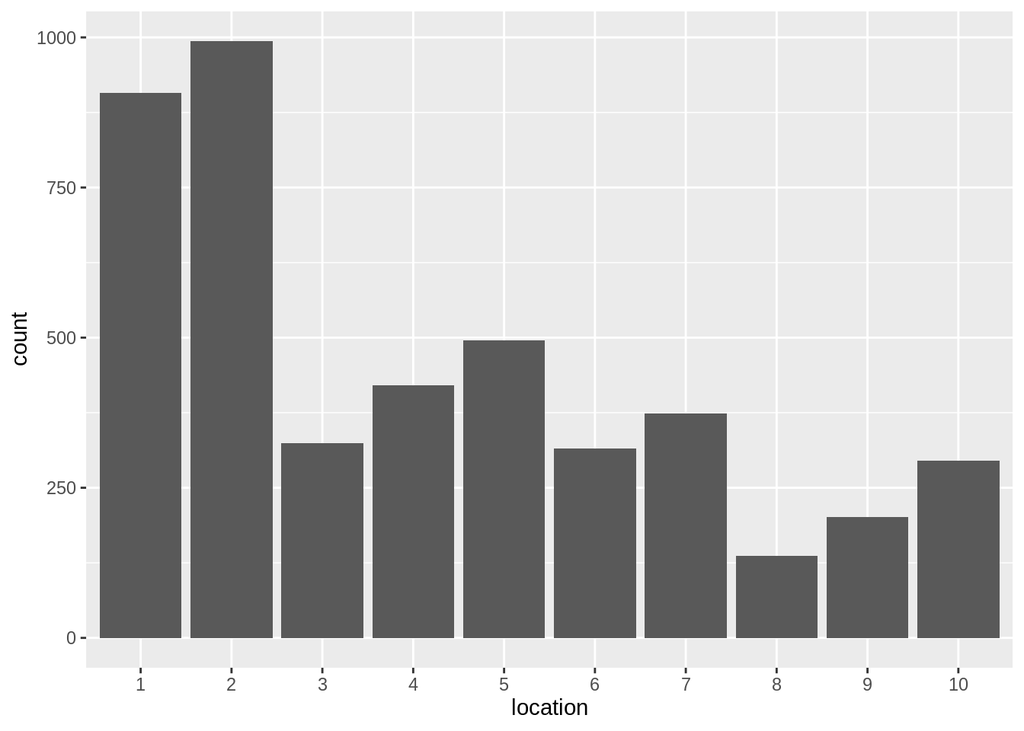

```r
transactions %>%
  distinct(customer_id, location) %>%
ggplot(aes(x = location)) + geom_bar()
```

#### monthly_amount - Total transaction amount for customer in given month

##### Top level info

- Range from 0 to 100,000,000
- Median 179399
- Mean 395397

##### Changes to make

- x

##### Questions

- Why are there transactions worth 0? ** How many transactions worth 0?

```r
zero_trans <- transactions %>%
  filter(monthly_amount == 0)

zero_trans
```

```
## # A tibble: 1 x 5
##   date       customer_id                      industry location monthly_amount
##   <date>     <fct>                            <fct>    <fct>             <dbl>
## 1 15-03-01   23755432da68528f115c9633c0d7834f 6        1                     0
```

```r
#A. only one transaction with amount 0, error?
```

*** How many transactions by that customer?

```r
transactions %>%
  filter(customer_id == zero_trans$customer_id) %>%
  nrow()
```

```
## [1] 28
```

- Why are there transactions worth 100,000,000 ** How many transactions are worth 100,000,000

```r
large_trans <- transactions %>%
  filter(monthly_amount == 100000000)

large_trans
```

```
## # A tibble: 1 x 5
##   date       customer_id                      industry location monthly_amount
##   <date>     <fct>                            <fct>    <fct>             <dbl>
## 1 16-10-01   ecf4afbea9a7f57c4c6da70593361d67 6        1             100000000
```

```r
#only one transaction of 100mm

largeish_trans <- transactions %>%
  filter(monthly_amount >= 50000000)

largeish_trans
```

```
## # A tibble: 42 x 5
##    date       customer_id                      industry location monthly_amount
##    <date>     <fct>                            <fct>    <fct>             <dbl>
##  1 13-01-01   23755432da68528f115c9633c0d7834f 6        1             51543872.
##  2 13-06-01   23755432da68528f115c9633c0d7834f 6        1             54222693.
##  3 13-07-01   23755432da68528f115c9633c0d7834f 6        1             56872964.
##  4 13-08-01   23755432da68528f115c9633c0d7834f 6        1             56369520.
##  5 13-09-01   23755432da68528f115c9633c0d7834f 6        1             61049749.
##  6 13-10-01   23755432da68528f115c9633c0d7834f 6        1             61513465.
##  7 13-11-01   23755432da68528f115c9633c0d7834f 6        1             59452274.
##  8 13-12-01   23755432da68528f115c9633c0d7834f 6        1             71974469.
##  9 14-01-01   23755432da68528f115c9633c0d7834f 6        1             63385958.
## 10 14-03-01   23755432da68528f115c9633c0d7834f 6        1             53960928.
## # … with 32 more rows
```

** Is this an arbitrary value? * Does most business fall within a certain range? * What is the distribution of transactions?

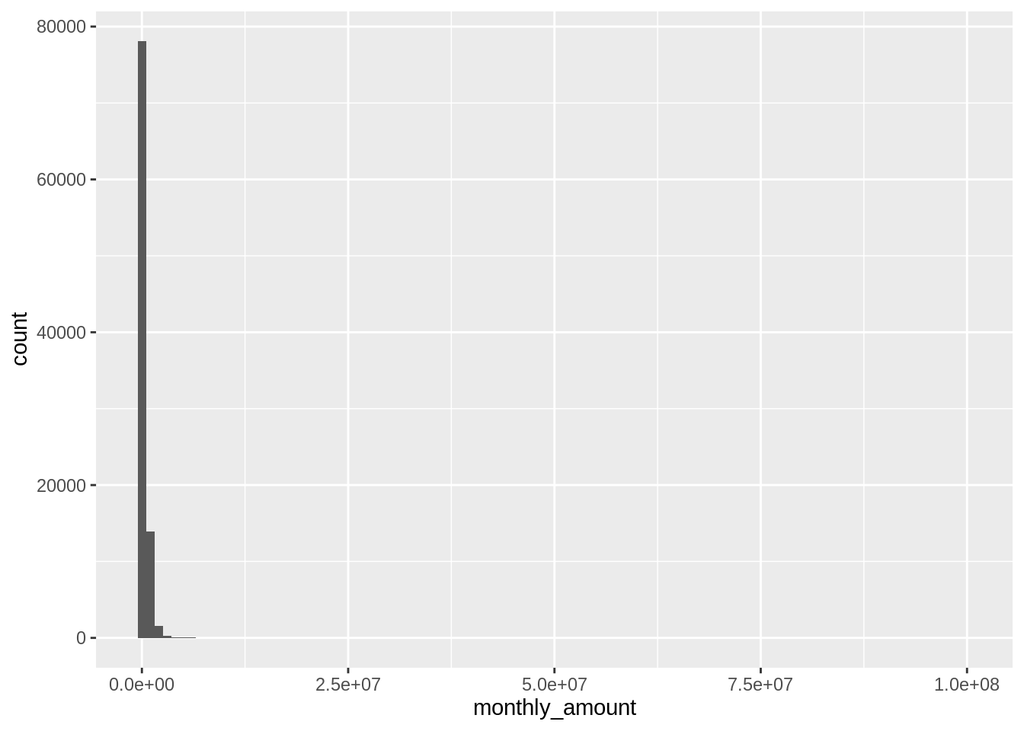

```r
ggplot(transactions, aes(x = monthly_amount)) + geom_histogram(bins = 100)
```

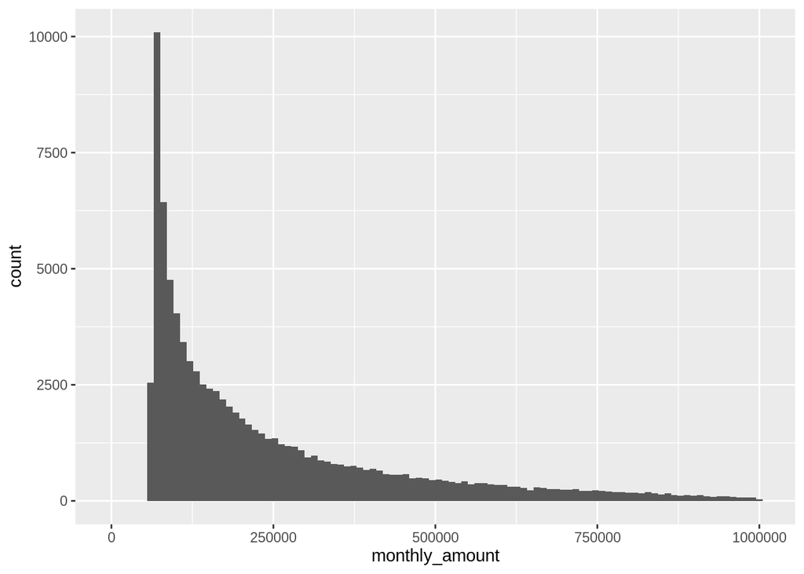

```r
# A. Distribution is heavily skewed toward the lower end of the range

transactions %>%
  filter(monthly_amount <= 1000000) %>%

ggplot(aes(x = monthly_amount)) + geom_histogram(bins  = 100)
```

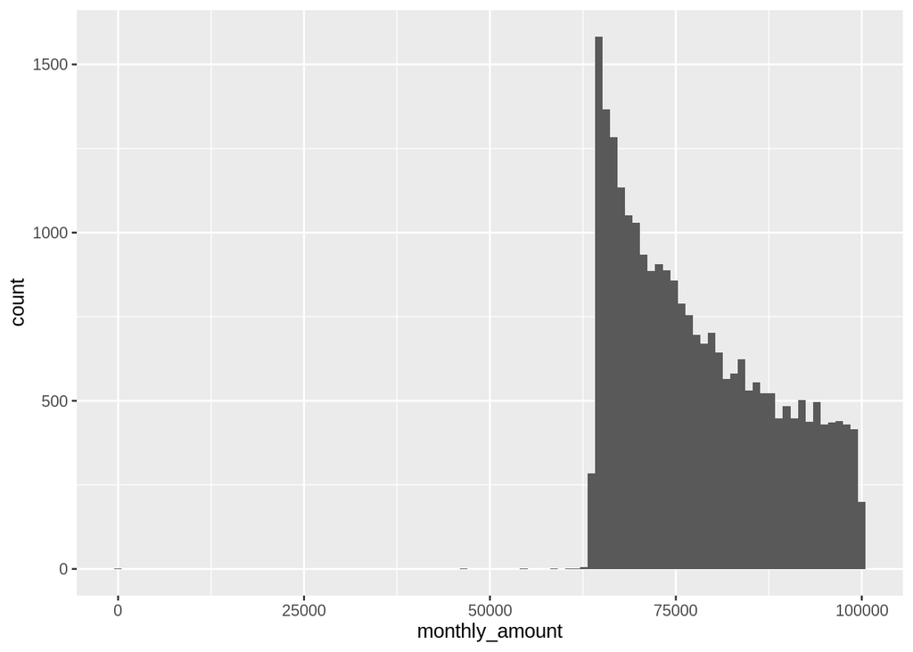

```r
# Still skewed heavily

transactions %>%
  filter(monthly_amount <= 100000) %>%

ggplot(aes(x = monthly_amount)) + geom_histogram(bins  = 100)
```

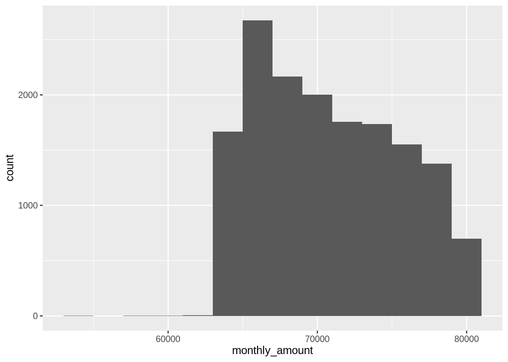

```r
#It appears most billing is cut

transactions %>%
  filter(monthly_amount <= 80000 & monthly_amount >= 50000) %>%

ggplot(aes(x = monthly_amount)) + geom_histogram(binwidth = 2000)
```

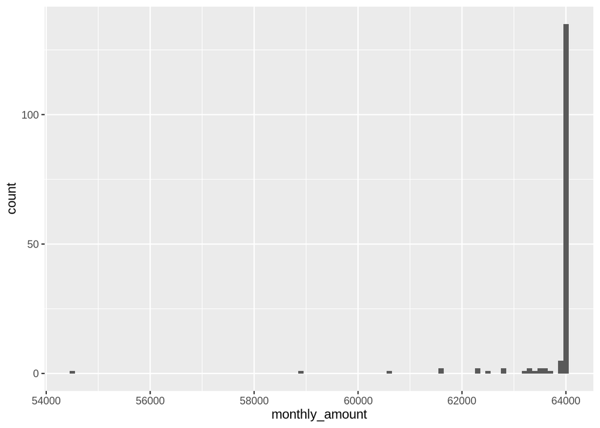

```r
# almost no transactions below 64000

transactions %>%
  filter(monthly_amount <= 64000 & monthly_amount >= 50000) %>%

ggplot(aes(x = monthly_amount)) + geom_histogram(binwidth = 100)
```

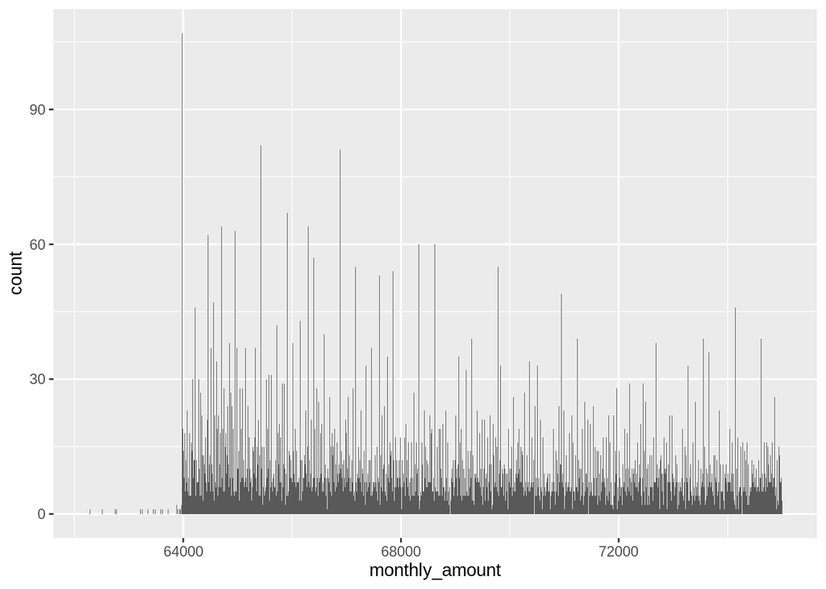

```r
transactions %>%
  filter(monthly_amount <= 75000 & monthly_amount >= 62000) %>%

ggplot(aes(x = monthly_amount)) + geom_histogram(binwidth = 10)
```

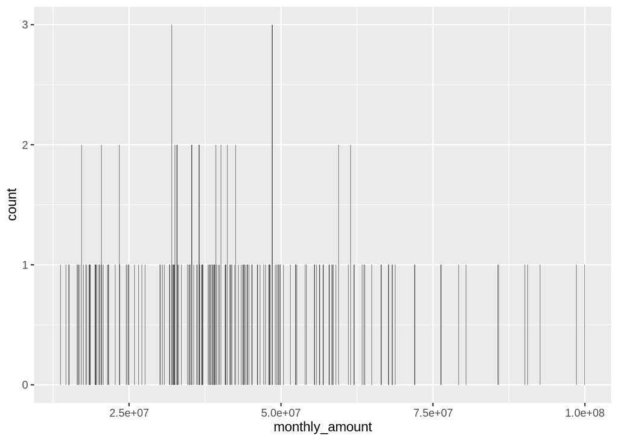

```r
transactions %>%
  filter(monthly_amount >= 10000000) %>%

ggplot(aes(x = monthly_amount)) + geom_histogram(bins = 1000)
```

- Are any fees “standard” ** Are they from the same customer?
- What is each customers total spend?

#### Exploration plots

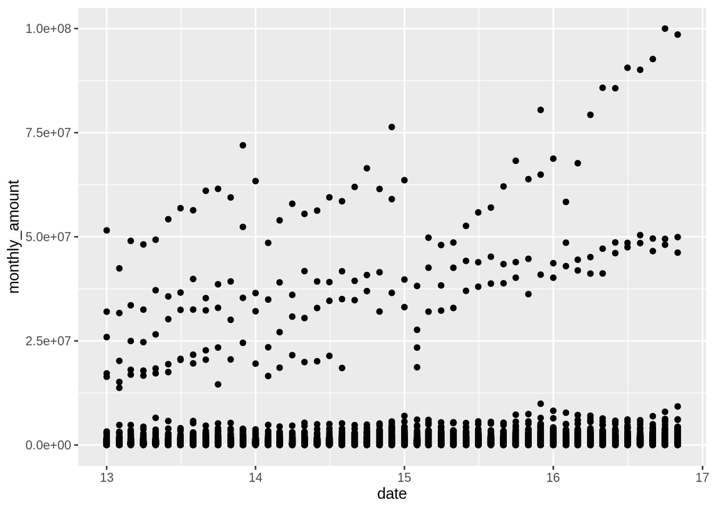

```r
ggplot(transactions, aes(x = date, y = monthly_amount)) + geom_point()
```

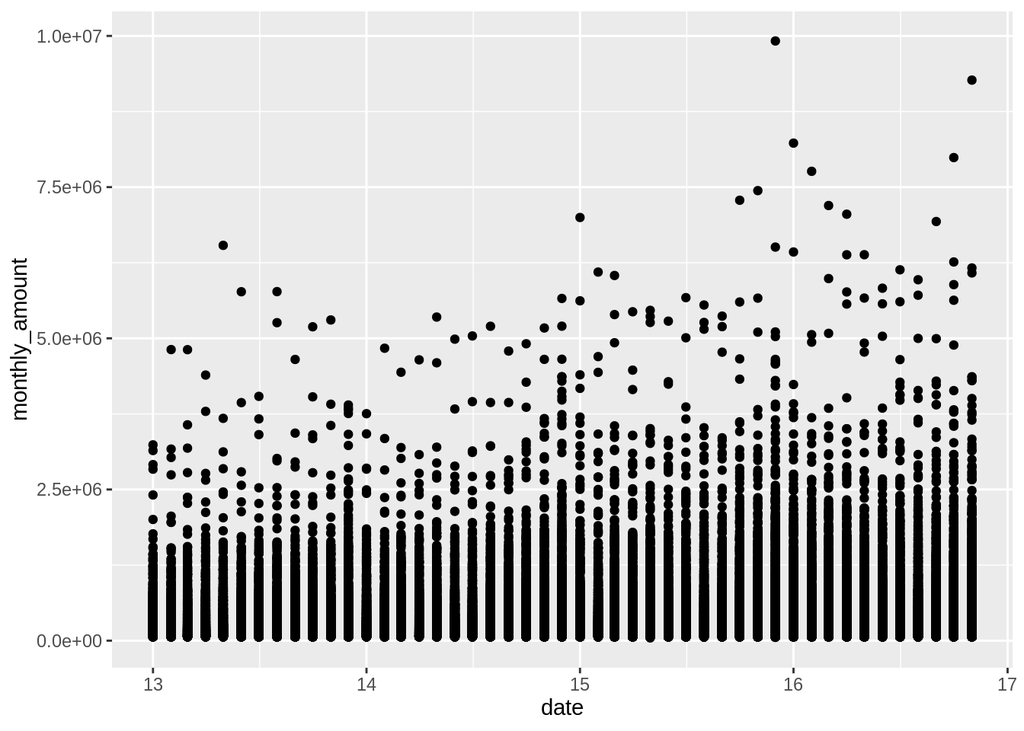

```r
ggplot(filter(transactions, industry != 6 & industry != 10), aes(x = date, y = monthly_amount)) + geom_point()
```

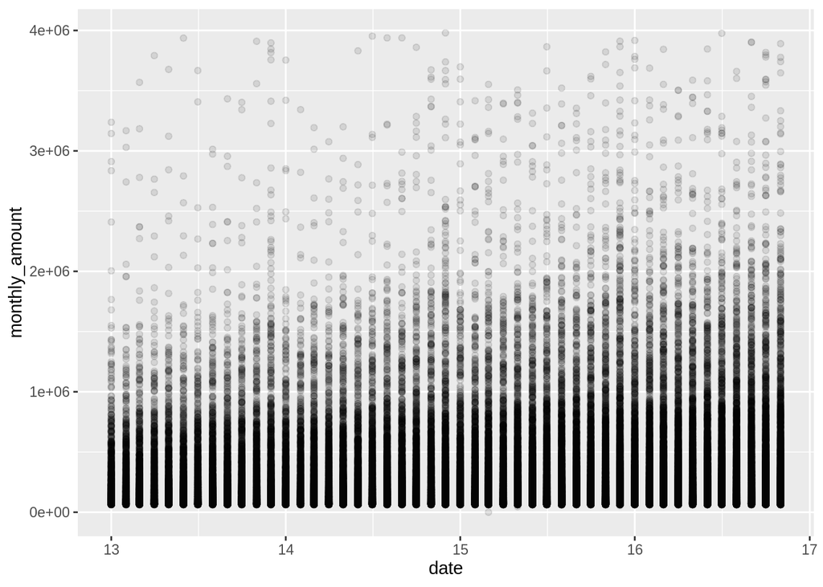

```r
transactions %>%
  filter(monthly_amount < 4000000) %>%
ggplot(aes(x = date, y = monthly_amount)) + geom_point(alpha = 0.1)
```

```r
# plot(transactions)
# long load
```

Split by industry

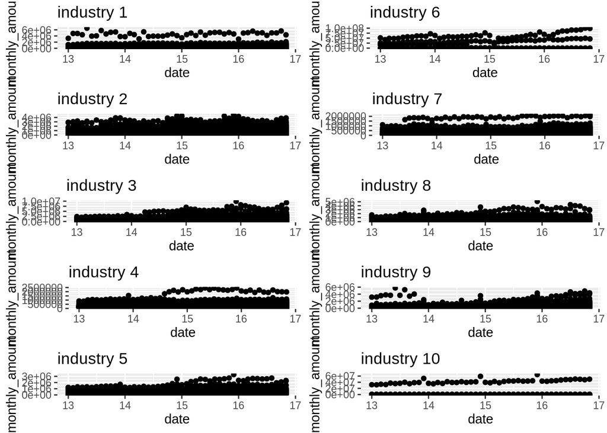

```r
for (indust in 1:10){
  dfname <- paste("transactions_industry", indust, sep = "_")
  dfind <- transactions %>%
    filter(industry == indust)
  assign(dfname, dfind)
}

plotlist_industry <- as.list(1:10)

plotlist_industry <- lapply(plotlist_industry, function(ind){
  ggplot(eval(as.symbol(paste("transactions_industry_", ind, sep=""))), aes(x = date, y = monthly_amount)) + geom_point() + labs (title = paste("industry", ind, sep = " "))
  })

multiplot(plotlist = plotlist_industry, cols = 2)
```

Split by location

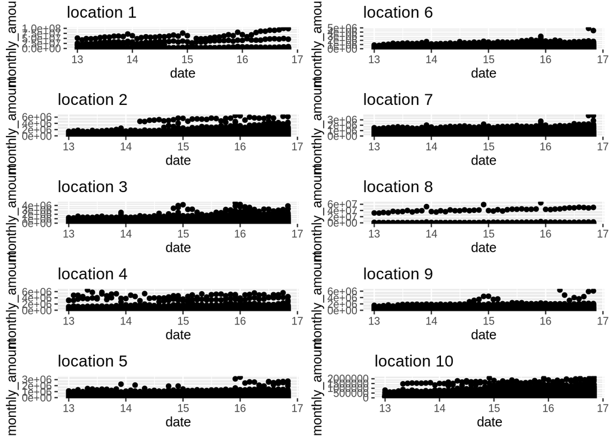

```r
for (locat in 1:10){
  dfname <- paste("transactions_location", locat, sep = "_")
  dfind <- transactions %>%
    filter(location== locat)
  assign(dfname, dfind)
}

plotlist_location <- as.list(1:10)

plotlist_location <- lapply(plotlist_location, function(loc){
  ggplot(eval(as.symbol(paste("transactions_location_", loc, sep=""))), aes(x = date, y = monthly_amount)) + geom_point() + labs (title = paste("location", loc, sep = " "))
  })

multiplot(plotlist = plotlist_location, cols = 2)
```

Split industry by location

[figure not shown]

```r
# modified code from CANVAS Announcement
# industry_location is the aggregated data frame
plotlist_loc_ind <- data.frame()
industries = unique(transactions$industry)
locations = unique(transactions$location)
for (ind in industries) {
for (loc in locations) {
  temp_name <- paste("industry", ind, "location", loc, sep = "_")
# create a subset of the data
temp = transactions[transactions$industry == ind &
transactions$location == loc, ]
assign(temp_name, temp)
row <- cbind(temp_name)
plotlist_loc_ind <- rbind(plotlist_loc_ind, row)
}
}

plotlist_loc_ind <- as.list(as.character(plotlist_loc_ind$temp_name))

plotlist_loc_ind <- lapply(plotlist_loc_ind, function(plotlist_loc_ind){
  ggplot(eval(as.symbol(paste(plotlist_loc_ind))), aes(x = date, y = monthly_amount)) + geom_point(alpha = 0.25) + theme_void() + labs (title = paste(plotlist_loc_ind))
  })

multiplot(plotlist = plotlist_loc_ind, cols = 5)
```